# PSTAT 231 - Homework 6

Tomas

## Tree-Based Models

### Question 1

**Read in the data and set things up as in Homework 5.**

```r
set.seed(2381)

pokemon_raw = read.csv('Pokemon.csv')
pokemon = clean_names(pokemon_raw)

pokemon = pokemon %>%
  filter(type_1 %in%
           c("Bug", "Fire", "Grass", "Normal", "Water", "Psychic")) %>%
  mutate(type_1 = as.factor(type_1)) %>%
  mutate(legendary = as.factor(legendary)) %>%
  mutate(generation = as.factor(generation)) %>%
  mutate(generation = as.integer(generation))

pokemon_split = initial_split(pokemon, prop=0.80, strata=type_1)
pokemon_train = training(pokemon_split)
pokemon_test = testing(pokemon_split)

folds = vfold_cv(pokemon_train, v=5, strata=type_1)

recipe = recipe(type_1 ~ legendary + generation + sp_atk + attack + speed +
                  defense + hp + sp_def, data=pokemon_train) %>%
  step_dummy(legendary, generation) %>%
  step_center(all_predictors()) %>%
  step_scale(all_predictors())
```

### Question 2

**Create a correlation matrix of the training set, using the `corrplot` package. Note: You can choose how to handle the continuous variables for this plot; justify your decision(s). What relationships, if any, do you notice? Do these relationships make sense to you?** The following correlations are observed:

- There is a near perfect correlation between generation and x. This makes sense as x (a Pokemon’s Pokedex number) will be lower for earlier generations and greater for later generations.
- There is no correlation between x and any stat, and generation and any stat. This makes sense as each generation has Pokemon with different combinations of stats.
- There is a strong positive correlation between total and every other stat (hp, attack, defense, sp_atk, sp_def, speed). This makes sense as a Pokemon that has one high stat will have a relatively high total stat.
- There is also a positive correlation between the pairs (speed, attack) and (speed, sp_atk). This makes sense as Pokemon with high speeds will often between offensively-oriented.
- There are also correlations between all pairs of the hp, attack, defense, sp_atk, and sp_def. This is reasonable as Pokemon with one high stat tend to have decent other stats. In particular, stats tend to increase as a Pokemon evolves while one-stage Pokemon (such as legendary Pokemon) tend to have at least average stats.

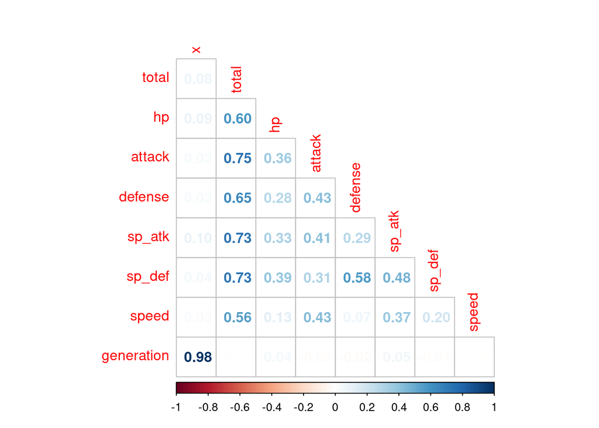

```r
pokemon_train %>%
  select(is.numeric) %>%
  cor() %>%
  corrplot(type="lower", diag=FALSE, method="number")
```